# Fitting the Demand, and Solving the Buy

Manuel D. Rossetti, PhD P.E.

## Agenda

- Look, summarize, hypothesize, estimate, test
- The one statistic that decides the family **before any test runs**
- What a goodness of fit test does, and does not, settle
- When a history is mostly zeros
- The belt, solved: **475** against a mean of 465
- Why the optimum is flat, and what the choice of family costs

## The Distribution Carries More Than the Formula

Every model from here to the end of the course takes a **demand distribution** as an input.

And the distribution carries more of the answer than the policy formula built on top of it does.

The distributor has **104 weeks** of demand for the belt, recorded after the deck went out of production.

One difference from the general procedure matters here: demand for a spare part is a **count**, so every tool is a **discrete** one.

## Read the Data as Data

```kotlin
val df = DataFrame.readCSV(
    File("data/ch7-weekly-demand.csv"),
    colTypes = mapOf("week" to ColType.Int, "demand" to ColType.Int)
)
val history: IntArray = df.getColumn("demand").toList().map { it as Int }.toIntArray()
```

Notice that the column types are **named** rather than left to be inferred.

A column of counts silently read as text, or as real numbers, fails **later** and **somewhere else**.

## Look Before You Model

A summary statistic answers a question you **already thought to ask**.

A picture shows you the thing you **did not**.

Three plots answer three different questions.

```kotlin
val h = Histogram(Histogram.createBreakPoints(0.0, 12, 10.0), "Weekly demand")
h.collect(history.toDoubles())
h.histogramPlot().showInBrowser()

ObservationsPlot(history.toDoubles()).showInBrowser()
ACFPlot(history.toDoubles()).showInBrowser()
```

## What Shape Is It?

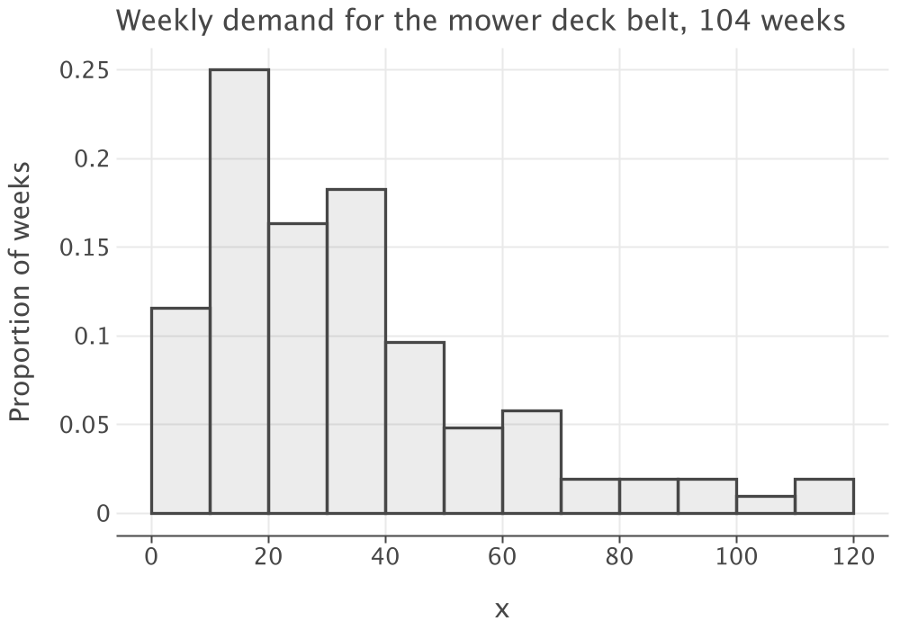

Weekly demand over 104 weeks, in bins of ten belts.

## Reading the Histogram

A peak **well to the left**.

A long thin tail reaching **past 110**.

**No suggestion of symmetry anywhere in it.**

That single picture has already ruled out the **normal distribution**.

## The Weeks in the Order They Occurred

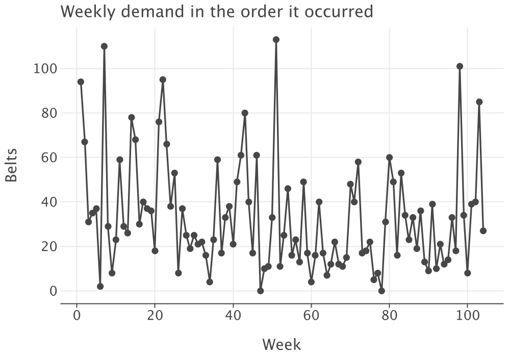

## Is It the Same Process Throughout?

Plot the weeks **in the order they occurred**. Look for a trend, a level shift, or a season.

There is none of those: the series wanders about a **constant level** for two years.

That matters, because it means **the season really is over**, which the problem statement claimed and this plot lets a reader **check** rather than accept.

## Autocorrelation Through Twenty Lags

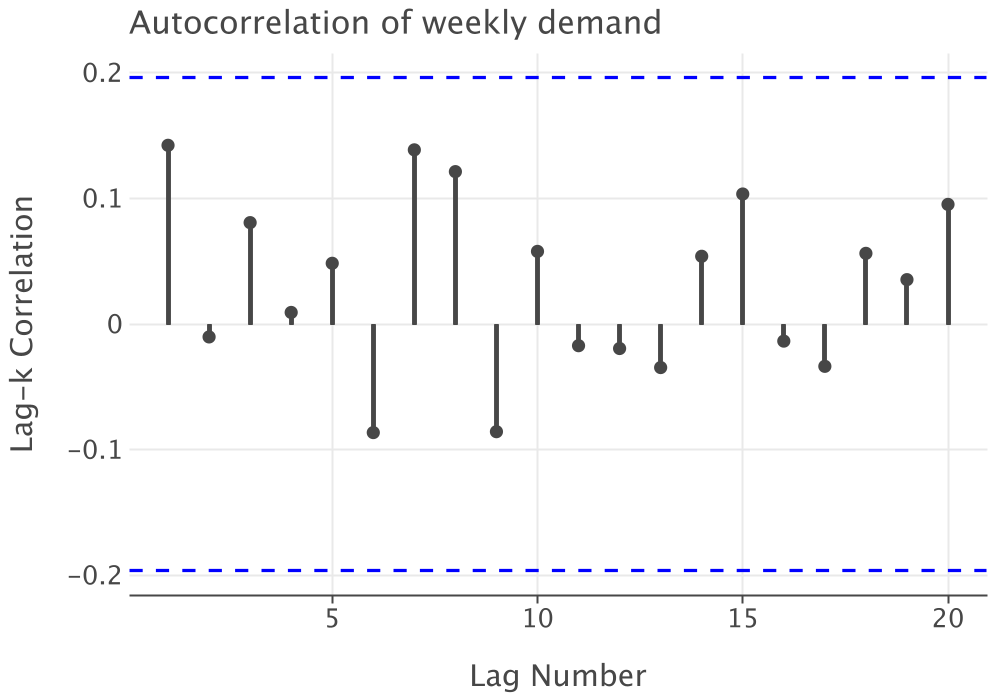

## Are the Weeks Independent?

The autocorrelation plot. Every lag falls **inside the band**, including the first, whose correlation is **0.1423** against a band of about

$$\pm 1.96/\sqrt{104} = \pm 0.19$$

Autocorrelated demand **breaks the variance of a sum**.

We are about to add **fourteen** of these weeks together and treat their variances as adding. This is the plot that licenses that arithmetic.

Taken together: the weeks are **independent, identically distributed, and strongly right-skewed**.

## Summarize It

| Statistic | Value |  | Statistic | Value |
| --- | --- | --- | --- | --- |
| Weeks observed | 104 |  | Skewness | 1.2630 |
| Mean | 33.2404 |  | Smallest week | 0 |
| Variance | 613.0387 |  | First quartile | 16.0 |
| Standard deviation | 24.7596 |  | Median | 26.5 |
| Coefficient of variation | 0.7449 |  | Third quartile | 40.0 |
| **Variance to mean ratio** | **18.4426** |  | Largest week | 113 |
|  |  |  | Weeks with no demand | 2 |

Read three things off this before going further.

## One: The Median Sits Well Below the Mean

A median of **26.5** against a mean of **33.24** says the distribution is **right-skewed**: most weeks are quiet and a few are very large.

The skewness of **1.2630** is the same statement with a number attached.

The histogram is the same statement with a picture attached.

Three routes, one finding.

## Two: Demand Is a Count

The weeks are **whole belts**. Two of them are **zero**. The quantity has no meaning between whole numbers.

So the families to consider are the **discrete** ones, and not the continuous ones.

## Three: For a Count, the Diagnostic Is the Variance to Mean Ratio

Not the coefficient of variation, because the **ratio** is what each discrete family fixes or bounds.

$$\mathit{VMR} = \frac{613.0387}{33.2404} = 18.44$$

## Step 1, Hypothesize

The ratio does most of this step by itself.

The **Poisson** fixes $\mathit{VMR} = 1$. The **binomial** forces $\mathit{VMR} < 1$.

A ratio of **18.44** is near neither, and **no choice of parameter repairs that**, because in both families the variance is decided the moment the mean is estimated.

What remains is the **negative binomial**, which admits any $\mathit{VMR} > 1$, and which is the Poisson with its **constant-rate assumption relaxed**.

That is a plausible story for a spare part: the rate at which mower decks need belts is not the same in every week.

## Step 2, Estimate

```kotlin
val modeler = PMFModeler(history)
for (result in modeler.estimateParameters(modeler.defaultEstimators)) {
    println(if (result.success) "${result.parameters}" else "FAILED: ${result.message}")
}
```

```
RV Type = NegativeBinomial
Double Parameters {probOfSuccess=0.05422232292974839, numSuccesses=1.9057024844439698}
RV Type = Poisson
Double Parameters {mean=33.24038461538462}
FAILED: Cannot match moments when sample average <= estimated variance
RV Type = Binomial
Double Parameters {probOfSuccess=0.29133420825260514, numTrials=114.09708737864078}
```

**The most useful line in that output is the failure.**

## The Software Performed Step 1

The moment-matching binomial estimator **refuses to return an answer**, and the reason it gives is the variance to mean ratio in words.

The binomial that **did** return an answer did so by matching the **largest observation** instead of the moments.

It reports **114.1 trials**: a fractional number of trials, for a quantity that has no trials in it.

An estimate being returned is not the same thing as a family being appropriate.

## Confirm the Estimate by Hand

Matching the negative binomial to the sample mean and variance:

$$\hat{p} = \frac{\bar{x}}{s^{2}} = \frac{33.2404}{613.0387} = 0.054222$$

$$\hat{r} = \frac{\bar{x}^{2}}{s^{2}-\bar{x}} = \frac{33.2404^{2}}{613.0387-33.2404} = 1.9057$$

Notice that $1/\hat{p} = 18.44$ is the **variance to mean ratio we started with**.

So the fitted $\hat{p}$ carries **no information the summary did not already have**.

That is true of the method of moments generally: the fit is a restatement of two summary numbers in the parameters of a family.

## Step 3, Test

A chi-squared goodness of fit test, on bins of approximately equal probability.

| Model | $\chi^{2}$ | d.f. | $p$-value | At the 0.05 level |
| --- | --- | --- | --- | --- |
| Negative binomial, $\hat{p}=0.0542$, $\hat{r}=1.9057$ | 23.35 | 17 | 0.1382 | do not reject |
| Poisson, $\hat{\lambda}=33.2404$ | 571.98 | 16 | 0.0000 | reject |

The Poisson is **not** rejected narrowly. Its test statistic is more than **twenty times** the negative binomial’s.

The table is the **confirmation**, not the decision.

The decision was made by the variance to mean ratio. A test that **contradicted** it would be telling us something is wrong with the **data**.

## The Fitted Model Against the Data

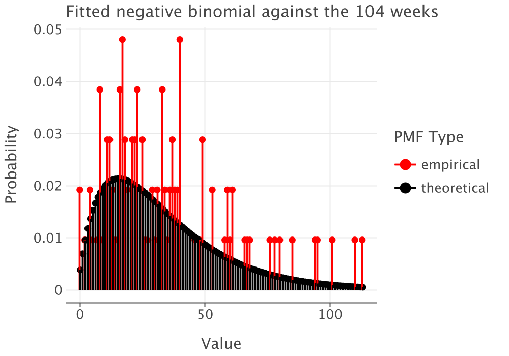

## Reading the Comparison

The empirical mass function is **spiky because it has to be**: 104 observations spread over 54 distinct values put a mass of $1/104$ or $2/104$ on most of them.

Which is exactly why the test **bins** before it tests.

What to read here is whether the fitted curve runs **through the middle** of the empirical forest.

It does.

## What the Test Does Not Settle

A goodness of fit test asks whether the data are **inconsistent** with a family. Failing to reject is **not proof**.

With 104 observations over twenty bins, several bins carry an expected count below five, which is where the chi-squared approximation is **least trustworthy**.

The test and the ratio **narrow the field**. The choice among what survives is yours to defend.

Where two survivors disagree enough to change the decision: compute the answer under **both** and report the spread.

## And What It Did Not Do

It did **not deseasonalize**, because there is nothing to remove and the season is over.

It did **not forecast**, which is a different job from fitting a distribution.

It did **not correct for censoring**, because the distributor does not record lost sales.

That last one is the limitation from last session, and **no amount of care here repairs it**.

## When the History Is Mostly Zeros

The belt sold in **102 of its 104 weeks**. Many items are not like that.

Classify a history by two statistics: the average interval between demands $\mathit{ADI}$, and the squared coefficient of variation of the **non-zero sizes** $\mathit{CV}^{2}$.

$\mathit{ADI} > 1.32$ is **intermittent**. Also $\mathit{CV}^{2} > 0.49$ is **lumpy**.

Those cut-offs are **not conventions**. They are the points at which one forecasting method overtakes another, which is why they are so oddly specific.

For the belt, $\mathit{ADI} = 104/102 = 1.02$. Comfortably under, which is the check that licensed everything above.

## Two Things Go Wrong Otherwise

**A single family has to explain two different things.** Period demand for an intermittent item is a **mixture**: a point mass at zero, and a distribution of sizes. Fitting one family forces it to account for **how often** demand happens and **how large** it is at once.

**The coefficient of variation goes past where the normal is usable.** A normal model at $CV = 1.0$ puts **a sixth** of its probability below zero, and intermittent items routinely run past 1.0.

That is not a small error in a tail. It is a model asserting that demand is **frequently negative**.

## Forecasting Intermittent Demand Is a Different Question

Worth naming precisely enough that you can go and read it.

Exponentially smoothing an intermittent series **directly** is wrong: the smoothing is dragged toward zero by every empty period, so the estimate is **lowest just after a demand occurs**, which is precisely when the next one is least likely.

Croston’s method smooths **two** series instead, the **size** when a demand happens and the **interval** between demands, and combines them into a rate.

The obvious combination is **biased**: the ratio of two independent smoothed estimates does not estimate the ratio of their means. Syntetos and Boylan gave the correction.

**Fitting** asks what the distribution of demand is. **Forecasting** asks what next period’s demand will be. This chapter asks only the first.

## The Belt, Solved

Let $X$ represent total demand over the **fourteen** remaining weeks.

Weekly demands are independent, so the mean and variance of a sum **add**:

$$E[X] = 14(33.2404) = 465.37, \qquad \mathit{Var}[X] = 14(613.0387) = 8582.54$$

So $\sigma = 92.64$ belts, and the coefficient of variation is $92.64/465.37 = 0.1991$.

## Two Approximations, Both Earned

**Treating the total as continuous.** One belt is $1/92.64$, or **1.1%**, of the standard deviation of the total. Rounding cannot decide the answer.

The **weekly** data, where one belt is 4% of the standard deviation, would **not** have earned the same treatment.

**Using the normal.** We rejected the normal for **weekly** demand, at $CV = 0.7449$. The fourteen-week total has $CV = 0.1991$, and a normal at that coefficient puts essentially nothing below zero.

Safe here and not safe there, and the reason is that a **sum of many independent terms tends toward the normal** whatever the terms look like.

## The Quantity

$$\frac{c_{u}}{c_{u}+c_{o}} = \frac{45}{83} = 0.542169$$

Standardizing, $Q^{*} = \mu + z\sigma$ with $z = \Phi^{-1}(0.542169) = 0.1059$:

$$Q^{*} = 465.37 + 0.1059(92.64) = 475.18$$

The distributor orders **475 belts**.

## The Consequences

The standard normal loss function at $z = 0.1059$ is **0.3482**, so the expected shortage is $92.64(0.3482) = 32.26$ belts.

The expected leftover is $32.26 + 475.18 - 465.37 = 42.07$ belts.

The distributor expects to **scrap about 42 belts** and to **turn away about 32 dealers**.

$$E[C(Q^{*})] = 38(42.07) + 45(32.26) = 1598.71 + 1451.72 = \$3{,}050.43$$

## The Check

The other form of the expected cost must agree:

$$(45+38)(32.26) + 38(475.18 - 465.37) = 2677.62 + 372.81 = \$3{,}050.43$$

The two agree, which confirms **both** the loss function and the quantity computed from it.

Worth performing every time. It catches a missing $\sigma$ in the loss function immediately.

**In business terms:** expected profit is $45(465.37) - 3050.43 = \$17{,}891$. The distributor commits **$23,750** to buy 475 belts and expects to clear about **$17,900**.

## The Optimum Is Flat

Ordering the mean rounded to whole belts, **465**, costs **$3,068.88** against the optimum’s $3,050.43.

That is **0.6% worse**.

The EOQ is flat in the same way and for the same reason: the objective is smooth and its derivative **vanishes** at the optimum.

So the value of this calculation is **not the last belt**.

It is knowing that 475 is right and **700 is not**, and 700 costs **$8,930**, nearly three times the optimum.

## What the Choice of Family Costs

A sum of independent negative binomials sharing $p$ is negative binomial, so the fitted weekly model gives the fourteen-week distribution **exactly**.

| Model used to choose $Q$ | Normal | Lognormal | Gamma | Exact negative binomial |
| --- | --- | --- | --- | --- |
| $Q$, rounded to whole belts | 475 | 466 | **469** | **469** |
| Expected cost under the exact model | $3,061.28 | $3,057.19 | **$3,055.38** | **$3,055.38** |
| Penalty against the exact answer | 0.19% | 0.06% | 0.00% | 0.00% |

Read that as a **bound**, not a ranking. The worst of the three continuous families costs **0.19%** more than choosing correctly.

That spread is small **because $CV = 0.1991$**. It would not be small at the weekly 0.7449, which is another reason to fit carefully.

## The Normal’s Defect Was Real and Did Not Bite

A normal with this mean and standard deviation puts $\Phi(-5.02)$ below zero.

About **one in four million**.

That is a statement about **this aggregation**, not about the normal in general.

The same family applied to the **weekly** data would have put about **9%** of its mass below zero.

## What We Did Today

**The variance to mean ratio chose the family**, and the goodness of fit test confirmed it rather than deciding it.

**A fit by moments restates two summary numbers** in the parameters of a family, and carries no more information than they do.

**The normal was wrong weekly and safe over fourteen weeks**, and the reason is the coefficient of variation of the sum.

**The optimum is flat.** The value of the calculation is not the last belt. It is knowing that 475 is right and 700 is not.

**The choice of continuous family cost at most 0.19%**, and it would not have been that cheap at the weekly coefficient of variation.

## For Next Time

**Read before next session:** *Discrete Demand*, *Extensions*, and *Estimating the Answer by Simulation*.

Everything today leaned on a **continuous** approximation that this item earned. Next session is about the items that do not:

- The **staircase** rule, which is not an inverse
- A case where rounding the continuous answer buys one unit too many, at $3,800
- A stockout penalty, and stock already on hand, and what an **unbounded** answer means
- Computing the same answer by **sampling**, and why you do that on a problem you have already solved

One belt was **1.1%** of the standard deviation of the total. One transformer is going to be **40%** of it, and that changes the arithmetic.

⌂ Index